# Data analysis and visulization

Finally we came to the last part of the project and the most useful one where we get insights and information that we will lead our thoughts.

First i think it's important get more info about WeRateDogs, is the account active and posts periodically? what about interactions on these posts?

As an animal lover but has no knowledge about dog i'm interested to know in such community of dog lovers what is the most common dog breed between them and do that dog breed get high rating or interactions? on the other side there are dog stage..which stage people prefer most?

Let summarize to specific questions to be more clear. we will answer the following questions:

1. What's rate of account posts over time?
2. Are engagements with posts increase over time?
3. What the most common dog breed appeared in tweets?
4. Which breed got most intractions?
5. Which breed got most retweets?
6. Which dog stage has more ratings?

### 1. What's rate of account posts over time?

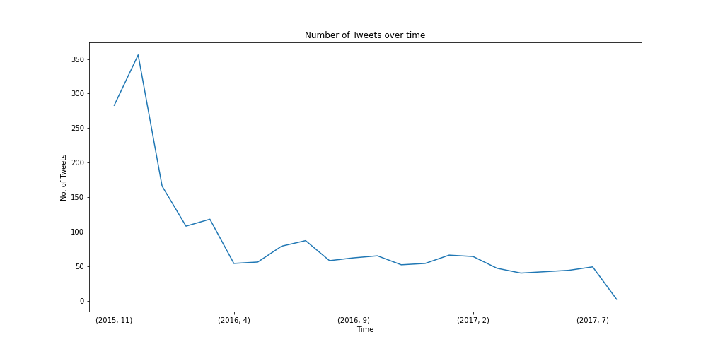

### 2. Do engagements with posts increase over time?

[figure not shown]

Interesting..interactions increase despite number of post on the account decrease over time. I think it might indicate high quality of posts.

### 3. what the most common dog breed appeared in tweets?

```
golden_retriever      137
Labrador_retriever     94
Pembroke               88
Chihuahua              78
pug                    54
                     ...
loupe                   1
trombone                1
school_bus              1
espresso                1
starfish                1
Name: prediction_1, Length: 365, dtype: int64
```

Golden retriever is the most common dog breed and Labrador retrieveris the second most common breed .. let's get more insights about dog breeds.

### 4. Which breed got most intractions?

```
        prediction_1    favorite_count
306  Lakeland_terrier       132810
766  Labrador_retriever  131075
58    English_springer     107956
397  Chihuahua            107015
108     French_bulldog       106827
... ... ...
1941    Gordon_setter   154
1924    toy_terrier 129
1925    black-and-tan_coonhound 113
1935    desktop_computer    108
1918    curly-coated_retriever  107
```

Lakeland terrier is the most breed that got interactions

### 5. Which breed got most retweets?

```
     prediction_1   retweet_count
766  Labrador_retriever 79515
397  Chihuahua          56625
801     Eskimo_dog          52360
306     Lakeland_terrier    48265
58      English_springer    45849
... ... ...
1924    toy_terrier         48
1819    crash_helmet        45
1925    black-and-tan_coonhound 44
1935    desktop_computer    37
1918    curly-coated_retriever  23
```

Labrador retriever got more retweets than others Despite Golden retriever appears more in tweets the interactions on its images not event in the top five! Labrador retriever is in a good poistion in both popularity in posts and interactions!

### 6. Which dog stage has more ratings ?

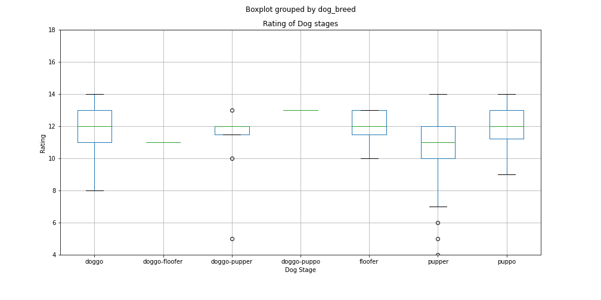

### Conclusion

We go through all steps to analyse the data,other work in cleaning and visualization processes can be done on the data and these insights can inspire others to more investigations and more accurate results.